### implementation of MLP, RNN and CNN on movie reviews sentiment analysis

```
library(data.table)
library(tidytext)
library(text2vec)
library(caret)
library(doSNOW)
library(SnowballC)
library(glmnet)
library(ROCR)
library(plyr)
library(ggplot2)
library(keras)
library(gridExtra)
```

keras 套件有提供 IMDB 資料集、搭配 pad_sequences 方法能實作 word embedding，不過我將延用前次練習所留下的資料集與參照字詞(字典)來實作。方法主要為MLP、RNN及CNN，參照字詞包括從訓練資料處理後的23908個詞彙、包含unlabeledTrainData.tsv處理後的33824個詞彙以及從中各取詞頻前3000、5000個詞彙，分別進行實驗。由於使用本身的參照字詞，我建立以下函式等同 pad_sequences 作用，將每一則 review 詞彙轉成數字、截長補短，生成固定長度的矩陣，方便後續 model 的建立

```r
# 截長補短,固定長度
makeFixedLength <- function(reviews, len = 150, vocabs) {
  tok.m = laply(reviews, function(rv, len, vocabs) {
    tokens = space_tokenizer(rv)[[1]]
    #只留有在字典的詞
    digitTK <- match(tokens, vocabs)
    digitTK <- digitTK[!is.na(digitTK)]

    TL <- length(digitTK)
    if(TL==0)
      rep(0, len)
    else if(TL < len)
      c(rep(0, len - TL), digitTK)
    else if(TL == len)
      digitTK
    else
      digitTK[-c(1:(TL - len))]

  }, len, vocabs)

  return(matrix(tok.m, nrow(tok.m)))
}
```

epochs 參數設定30，每則 review 詞的長度自訂150，詞向量維度自訂128，接著將 reviews 依各自參照字詞生成固定長度的矩陣

```r
epochs <- 30
maxlen <- 150
word_dim <- 128

# use 33824 vocabs of all reviews
train_tokens_av <- makeFixedLength(train$review3, maxlen, vocab_all$vocab$terms)
test_tokens_av <- makeFixedLength(test$review3, maxlen, vocab_all$vocab$terms)
max_features_av <- length(vocab_all$vocab$terms)


vocab_freq <- setorder(vocab_all$vocab, -terms_counts)
# use top freq 3000 vocabs of all reviews
vocab_freq3000 <- vocab_freq[1:3000,]
train_tokens_av3000 <- makeFixedLength(train$review3, maxlen, vocab_freq3000$terms)
test_tokens_av3000 <- makeFixedLength(test$review3, maxlen, vocab_freq3000$terms)
max_features_av3000 <- length(vocab_freq3000$terms)

# use top freq 5000 vocabs of all reviews
vocab_freq5000 <- vocab_freq[1:5000,]
train_tokens_av5000 <- makeFixedLength(train$review3, maxlen, vocab_freq5000$terms)
test_tokens_av5000 <- makeFixedLength(test$review3, maxlen, vocab_freq5000$terms)
max_features_av5000 <- length(vocab_freq5000$terms)
#-----------------------------

# use 23908 vocabs of train reviews
train_tokens_tv <- makeFixedLength(train$review3, maxlen, vocab$vocab$terms)
test_tokens_tv <- makeFixedLength(test$review3, maxlen, vocab$vocab$terms)
max_features_tv <- length(vocab$vocab$terms)


vocab_freq <- setorder(vocab$vocab, -terms_counts)
# use top freq 3000 vocabs of train reviews
vocab_freq3000 <- vocab_freq[1:3000,]
train_tokens_tv3000 <- makeFixedLength(train$review3, maxlen, vocab_freq3000$terms)
test_tokens_tv3000 <- makeFixedLength(test$review3, maxlen, vocab_freq3000$terms)
max_features_tv3000 <- length(vocab_freq3000$terms)

# use top freq 5000 vocabs of train reviews
vocab_freq5000 <- vocab_freq[1:5000,]
train_tokens_tv5000 <- makeFixedLength(train$review3, maxlen, vocab_freq5000$terms)
test_tokens_tv5000 <- makeFixedLength(test$review3, maxlen, vocab_freq5000$terms)
max_features_tv5000 <- length(vocab_freq5000$terms)
```

MLP model 設定如下，避免過度擬合dropout自訂0.5，隱藏層自訂6層，學習率自訂0.0015，衰退率自訂0.05

```r
# train MLP
fitMLP <- function(max_features, train_tokens, test_tokens) {
  model <- keras_model_sequential()
  model %>%
    layer_embedding(input_dim = max_features, output_dim = word_dim, input_length = maxlen) %>%
    layer_dropout(0.5) %>%
    layer_flatten() %>%
    layer_dense(units = 1024, activation = 'relu') %>%
    layer_dropout(0.5) %>%
    layer_dense(units = 1024, activation = 'relu') %>%
    layer_dropout(0.5) %>%
    layer_dense(units = 512, activation = 'relu') %>%
    layer_dropout(0.5) %>%
    layer_dense(units = 512, activation = 'relu') %>%
    layer_dropout(0.5) %>%
    layer_dense(units = 128, activation = 'relu') %>%
    layer_dropout(0.5) %>%
    layer_dense(units = 128, activation = 'relu') %>%
    layer_dense(units = 1, activation = 'sigmoid')

  model %>% compile(
    loss = "binary_crossentropy",
    optimizer = optimizer_adam(lr = 0.0015, decay = 0.05),
    metrics = "accuracy"
  )

  MLP_result <- model %>%
    fit(train_tokens, train$sentiment, batch_size = 100, epochs = epochs,
        validation_data = list(test_tokens, test$sentiment)
    )
  return(MLP_result)
}
```

RNN model 參數設定大致相同，除了將平坦層換成output為32個神經元的RNN層…

```r
# train RNN
fitRNN <- function(max_features, train_tokens, test_tokens) {
  model <- keras_model_sequential()
  model %>%
    layer_embedding(input_dim = max_features, output_dim = word_dim, input_length = maxlen) %>%
    layer_dropout(0.5) %>%
    layer_simple_rnn(units = 32) %>%
    layer_dense(units = 1024, activation = 'relu') %>%
    layer_dropout(0.5) %>%
    layer_dense(units = 1024, activation = 'relu') %>%
    layer_dropout(0.5) %>%
    layer_dense(units = 512, activation = 'relu') %>%
    layer_dropout(0.5) %>%
    layer_dense(units = 512, activation = 'relu') %>%
    layer_dropout(0.5) %>%
    layer_dense(units = 128, activation = 'relu') %>%
    layer_dropout(0.5) %>%
    layer_dense(units = 128, activation = 'relu') %>%
    layer_dense(units = 1, activation = 'sigmoid')

  model %>% compile(
    loss = "binary_crossentropy",
    optimizer = optimizer_adam(lr = 0.0015, decay = 0.05),
    metrics = "accuracy"
  )

  RNN_result <- model %>%
    fit(train_tokens, train$sentiment, batch_size = 100, epochs = epochs,
        validation_data = list(test_tokens, test$sentiment)
    )
  return(RNN_result)
}
```

CNN model 參數設定也大致相同，除了在平坦層前多加了一維的卷積層…

```r
# train CNN
fitCNN <- function(max_features, train_tokens, test_tokens) {
  model <- keras_model_sequential()
  model %>%
    layer_embedding(input_dim = max_features, output_dim = word_dim, input_length = maxlen) %>%
    layer_dropout(0.5) %>%
    layer_conv_1d(filters = 64, kernel_size = 4, padding = "valid", activation = "tanh", strides = 1) %>%
    layer_flatten() %>%
    layer_dense(units = 1024, activation = 'relu') %>%
    layer_dropout(0.5) %>%
    layer_dense(units = 1024, activation = 'relu') %>%
    layer_dropout(0.5) %>%
    layer_dense(units = 512, activation = 'relu') %>%
    layer_dropout(0.5) %>%
    layer_dense(units = 512, activation = 'relu') %>%
    layer_dropout(0.5) %>%
    layer_dense(units = 128, activation = 'relu') %>%
    layer_dropout(0.5) %>%
    layer_dense(units = 128, activation = 'relu') %>%
    layer_dense(units = 1, activation = 'sigmoid')

  model %>% compile(
    loss = "binary_crossentropy",
    optimizer = optimizer_adam(lr = 0.0015, decay = 0.05),
    metrics = "accuracy"
  )

  CNN_result <- model %>%
    fit(train_tokens, train$sentiment, batch_size = 100, epochs = epochs,
        validation_data = list(test_tokens, test$sentiment)
    )
  return(CNN_result)
}
```

#### **使用所有評論33824個詞彙**

```r
MLP_av <- fitMLP(max_features_av, train_tokens_av, test_tokens_av)
RNN_av <- fitRNN(max_features_av, train_tokens_av, test_tokens_av)
CNN_av <- fitCNN(max_features_av, train_tokens_av, test_tokens_av)
```

在第30次epoch的val_acc，MLP為0.8496，RNN為0.8568，CNN為0.8562667。其中以RNN最高，CNN次之，RNN在epoch為5之後就開始收斂現象，不過隨著epoch增加後面有點overfitting感覺，不過MLP的overfitting更明顯

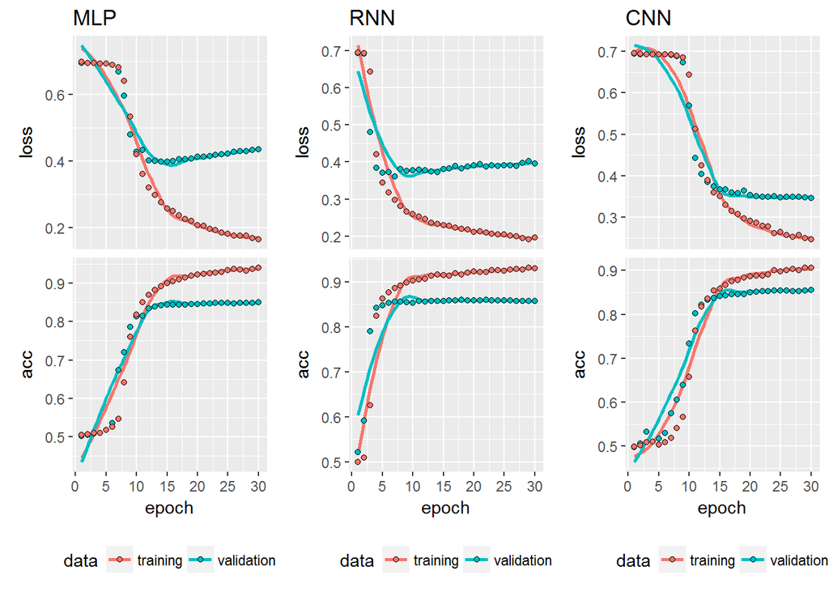

#### **使用所有評論中詞頻前3000個詞彙**

```r
MLP_av3000 <- fitMLP(max_features_av3000, train_tokens_av3000, test_tokens_av3000)
RNN_av3000 <- fitRNN(max_features_av3000, train_tokens_av3000, test_tokens_av3000)
CNN_av3000 <- fitCNN(max_features_av3000, train_tokens_av3000, test_tokens_av3000)
```

在第30次epoch的val_acc，MLP為0.842，RNN為0.8509333，CNN為0.8482667。其中以RNN最高，CNN次之，RNN依然是最早收斂，和前次RNN相比較無overfitting現象，不過MLP的overfitting還是相對明顯

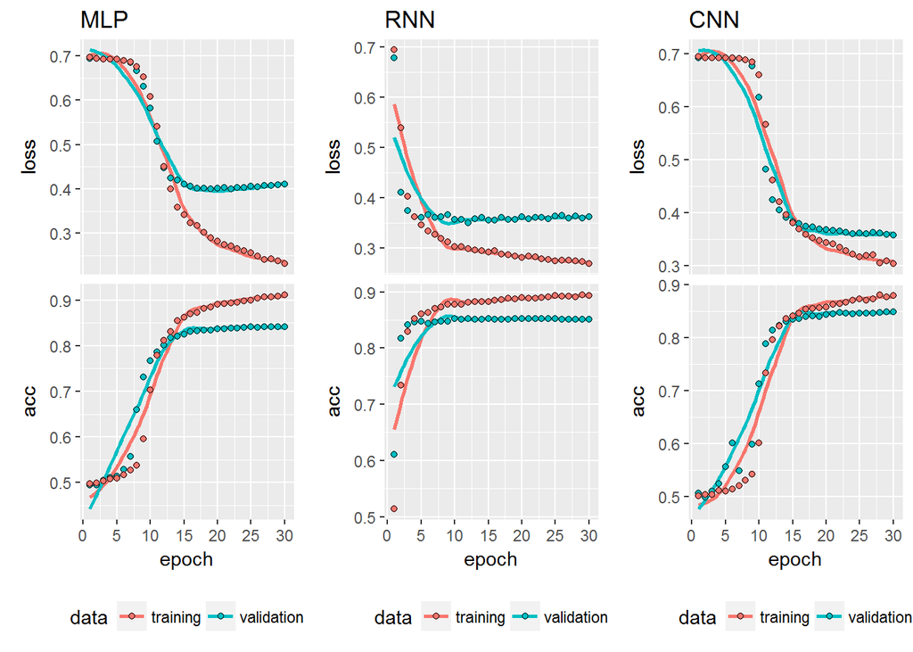

#### **使用所有評論中詞頻前5000個詞彙**

```r
MLP_av5000 <- fitMLP(max_features_av5000, train_tokens_av5000, test_tokens_av5000)
RNN_av5000 <- fitRNN(max_features_av5000, train_tokens_av5000, test_tokens_av5000)
CNN_av5000 <- fitCNN(max_features_av5000, train_tokens_av5000, test_tokens_av5000)
```

在第30次epoch的val_acc，MLP為0.8482667，RNN為0.8570667，CNN為0.8538667。其中還是以RNN最高，CNN次之，RNN一樣在epoch為5之後就步入收歛，相較於MLP也較無overfitting現象

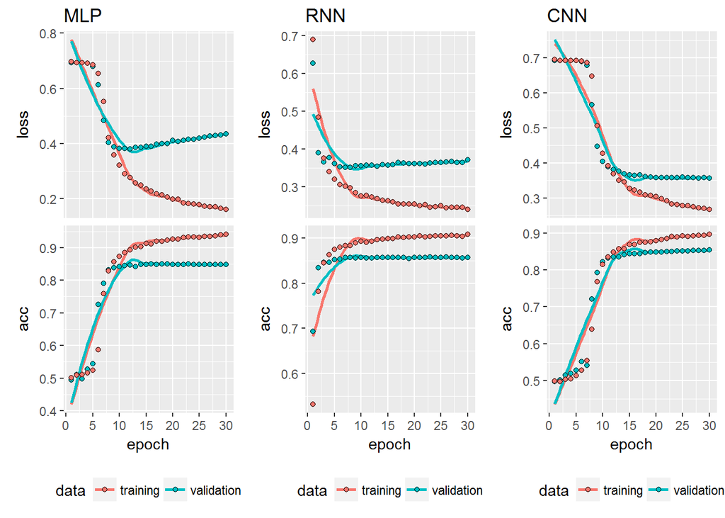

小結：從以上實驗結果看來，RNN表現最佳、CNN次之、MLP最差，在model訓練上，RNN收斂最快、較無overfitting現象，MLP的overfitting最明顯。另外，過多的參照字詞overfitting也比較明顯

#### **使用訓練資料23908個詞彙**

```r
MLP_tv <- fitMLP(max_features_tv, train_tokens_tv, test_tokens_tv)
RNN_tv <- fitRNN(max_features_tv, train_tokens_tv, test_tokens_tv)
CNN_tv <- fitCNN(max_features_tv, train_tokens_tv, test_tokens_tv)
```

在第30次epoch的val_acc，MLP為0.8349333，RNN為0.8593333，CNN為0.8534667。其中以RNN最高，CNN次之，RNN還是收斂最快，MLP則最慢，2者隨著epoch增加後面都有點overfitting

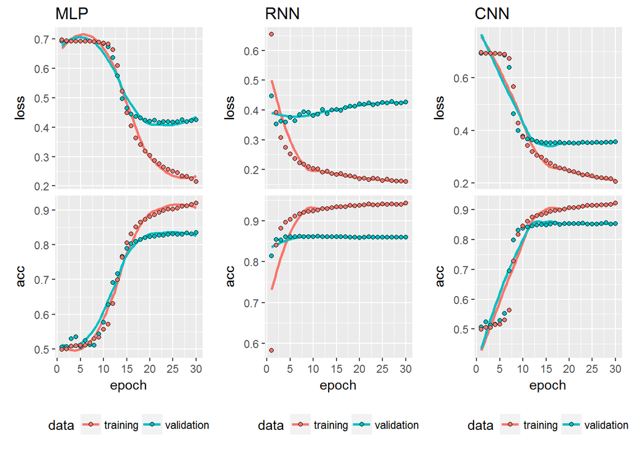

#### **使用訓練資料中詞頻前3000個詞彙**

```r
MLP_tv3000 <- fitMLP(max_features_tv3000, train_tokens_tv3000, test_tokens_tv3000)
RNN_tv3000 <- fitRNN(max_features_tv3000, train_tokens_tv3000, test_tokens_tv3000)
CNN_tv3000 <- fitCNN(max_features_tv3000, train_tokens_tv3000, test_tokens_tv3000)
```

在第30次epoch的val_acc，MLP為0.8301333，RNN為0.8517333，CNN為0.8513333。RNN還是最高，CNN次之，MLP依然墊底，相較於其他2者，MLP收斂最慢、overfitting最明顯，RNN在這方面表現最佳

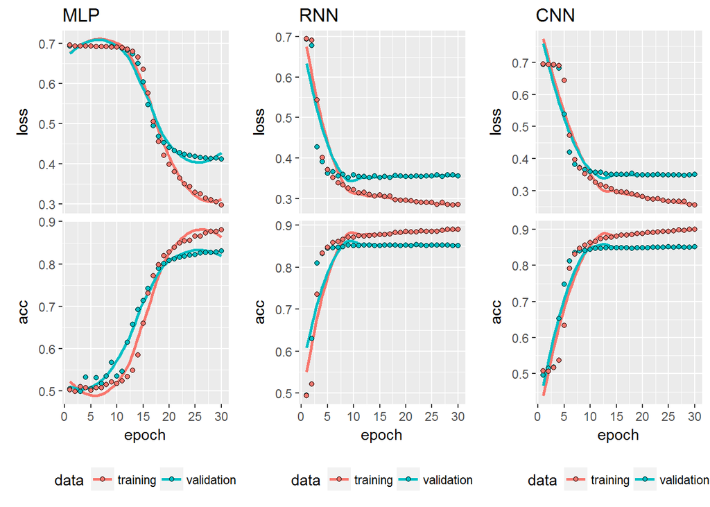

#### **使用訓練資料中詞頻前5000個詞彙**

```r
MLP_tv5000 <- fitMLP(max_features_tv5000, train_tokens_tv5000, test_tokens_tv5000)
RNN_tv5000 <- fitRNN(max_features_tv5000, train_tokens_tv5000, test_tokens_tv5000)
CNN_tv5000 <- fitCNN(max_features_tv5000, train_tokens_tv5000, test_tokens_tv5000)
```

在第30次epoch的val_acc，MLP為0.8468，RNN為0.8492，CNN為0.8514667。這次CNN最高，RNN次之，相較於其他2者，這次MLP在epoch為15後才有比較穩定的acc，不過從fitting現象看來屬RNN最佳

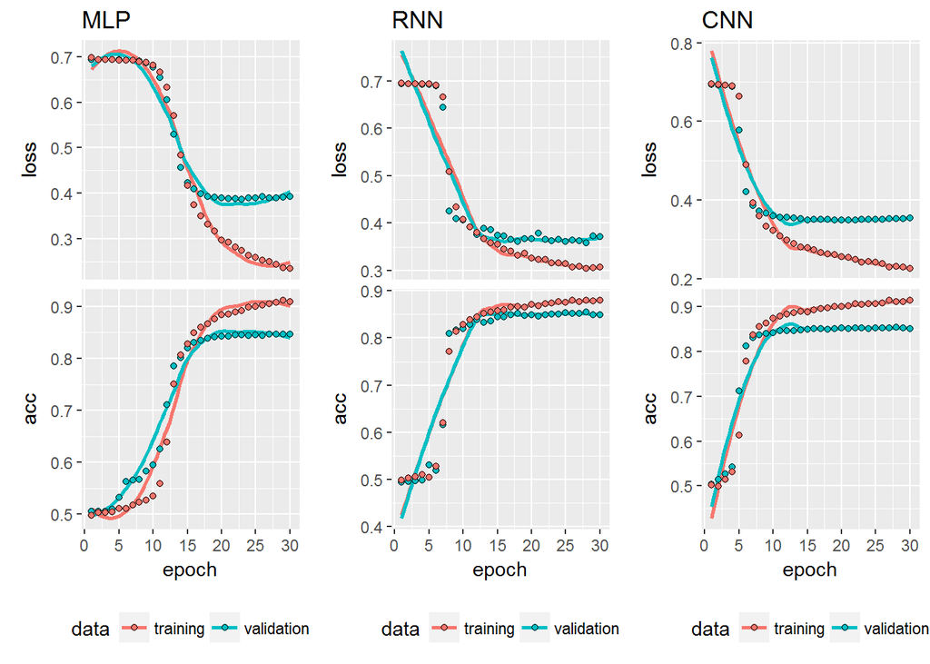

小結：從以上實驗結果看來，RNN有2次表現最佳、CNN則有1次，MLP表現依然不如這2者，在model訓練上，RNN收斂最快，CNN較無overfitting現象，MLP的overfitting最明顯。過多的參照字詞overfitting現象還是相對明顯

#### **Summary**

| vocab_words | MLP_acc | RNN_acc | CNN_acc | MLP_loss | RNN_loss | CNN_loss |
| --- | --- | --- | --- | --- | --- | --- |
| 33824 words of all reviews | 0.8496000 | 0.8568000 | 0.8562667 | 0.4356804 | 0.3961706 | 0.3468006 |
| 3000 words of all reviews | 0.8420000 | 0.8509333 | 0.8482667 | 0.4098230 | 0.3614354 | 0.3573428 |
| 5000 words of all reviews | 0.8482667 | 0.8570667 | 0.8538667 | 0.4346297 | 0.3712670 | 0.3570871 |
| 23908 words of train reviews | 0.8349333 | 0.8593333 | 0.8534667 | 0.4246089 | 0.4270120 | 0.3567831 |
| 3000 words of train reviews | 0.8301333 | 0.8517333 | 0.8513333 | 0.4120610 | 0.3558877 | 0.3509720 |
| 5000 words of train reviews | 0.8468000 | 0.8492000 | 0.8514667 | 0.3924710 | 0.3717013 | 0.3552072 |

這次實作MLP、RNN及CNN三種方法在電影評論分類任務上，分別使用了六種的參照字詞，透過 Keras 提供的embedding層將數字轉成向量，RNN在本次實驗上表現最佳，6次之中有5次有最高的accuracy，CNN則有1次，MLP方法在這三種之中表現是最差的。此外，RNN方法在訓練上最快收斂，也較無overfitting，MLP方法訓練收斂最慢、overfitting也相對明顯。在 loss 表現上，CNN則是最小、RNN次之。在參照字詞使用上，使用最多字詞並未有最高的accuracy，也可能造成較明顯的overfitting現象，當然運算成本也相對高，這是一個trade-off問題。